# Web Data: APIs and Scraping

```r
## Conclusion=> Country is not missing


# Step 12: Check if First Director is missing
# Identify First Director from the previous cleaned movierank dataframe:
datadf <- datadf %>%
  mutate(isfirst_dir = text %in% movierank$director_first)

sum(datadf$isfirst_dir)
```

```
## [1] 100
```

```r
## Conclusion=> First Director is not missing

head(datadf,22)
```

```
## # A tibble: 22 x 14
##    text  ismovierank movienum isname isyear isMPAA islength isgenre isimdb_score
##    <chr> <lgl>          <int> <lgl>  <lgl>  <lgl>  <lgl>    <lgl>   <lgl>
##  1 "1."  TRUE               1 FALSE  FALSE  FALSE  FALSE    FALSE   FALSE
##  2 "Cit~ FALSE              1 TRUE   FALSE  FALSE  FALSE    FALSE   FALSE
##  3 "(20~ FALSE              1 FALSE  TRUE   FALSE  FALSE    FALSE   FALSE
##  4 "R"   FALSE              1 FALSE  FALSE  TRUE   FALSE    FALSE   FALSE
##  5 "130~ FALSE              1 FALSE  FALSE  FALSE  TRUE     FALSE   FALSE
##  6 "\nC~ FALSE              1 FALSE  FALSE  FALSE  FALSE    TRUE    FALSE
##  7 "8.6" FALSE              1 FALSE  FALSE  FALSE  FALSE    FALSE   TRUE
##  8 "79 ~ FALSE              1 FALSE  FALSE  FALSE  FALSE    FALSE   FALSE
##  9 "Fer~ FALSE              1 FALSE  FALSE  FALSE  FALSE    FALSE   FALSE
## 10 "726~ FALSE              1 FALSE  FALSE  FALSE  FALSE    FALSE   FALSE
## # ... with 12 more rows, and 5 more variables: ismetascore <lgl>, isvote <lgl>,
## #   isreceipt <lgl>, iscountry <lgl>, isfirst_dir <lgl>
```

```r
missing_func <- function(data){
  return(100 - sum(data))
}

datadf %>%
  select(ismovierank,
         isname,
         isyear,
         isMPAA,
         islength,
         isgenre,
         isimdb_score,
         ismetascore,
         isvote,
         isreceipt,
         iscountry,
         isfirst_dir) %>%
  dplyr::summarise(across(.fns = missing_func))
```

```
## # A tibble: 1 x 12
##   ismovierank isname isyear isMPAA islength isgenre isimdb_score ismetascore
##         <dbl>  <dbl>  <dbl>  <dbl>    <dbl>   <dbl>        <dbl>       <dbl>
## 1           0      0      0     15        0       0            0          48
## # ... with 4 more variables: isvote <dbl>, isreceipt <dbl>, iscountry <dbl>,
## #   isfirst_dir <dbl>
```

```r
datawide <- datadf %>%
  mutate(key = case_when(ismovierank ~ "rank",
                         isname ~ "name",
                         isyear ~ "year",
                         isMPAA ~ "MPAA",
                         islength ~ "length",
                         isgenre ~ "genre",
                         isimdb_score ~ "starscore",
                         ismetascore ~ "metacscore",
                         isvote ~ "vote",
                         isreceipt ~ "gross_receipts",
                         iscountry ~ "Country",
                         isfirst_dir ~ "first_director")) %>%
  select(key, text, movienum) %>%
  pivot_wider(names_from = key, values_from = text)

head(datawide)
```

```
## # A tibble: 6 x 13
##   movienum rank  name      year   MPAA   length genre       starscore metacscore
##      <int> <chr> <chr>     <chr>  <chr>  <chr>  <chr>       <chr>     <chr>
## 1        1 1.    City of ~ (2002) R      130 m~ "\nCrime, ~ 8.6       "79      ~
## 2        2 2.    A Short ~ (1988) Not R~ 87 min "\nDrama, ~ 8.2        <NA>
## 3        3 3.    Battle R~ (2000) Not R~ 114 m~ "\nAction,~ 7.6       "81      ~
## 4        4 4.    Wild Tal~ (2014) R      122 m~ "\nComedy,~ 8.1       "77      ~
## 5        5 5.    Run Lola~ (1998) R      80 min "\nCrime, ~ 7.7       "77      ~
## 6        6 6.    The Hand~ (2016) Not R~ 145 m~ "\nDrama, ~ 8.1       "84      ~
## # ... with 4 more variables: first_director <chr>, vote <chr>,
## #   gross_receipts <chr>, Country <chr>
```

```r
datawide <- datawide %>%
  mutate(rank = parse_number(rank),
         name = str_squish(name),
         year = parse_number(year),
         MPAA = as.factor(MPAA),
         length = parse_number(length),
         genre = str_replace_all(genre, "\\n", ""),
         genre = str_squish(genre),
         starscore = parse_number(starscore),
         metacscore = parse_number(metacscore),
         vote = parse_number(vote),
         gross_receipts = parse_number(gross_receipts),
         Country = as.factor(str_sub(Country, start = 6)),
         first_director = str_squish(first_director)) %>%
  select(-movienum)

head(datawide)
```

```
## # A tibble: 6 x 12
##    rank name      year MPAA   length genre   starscore metacscore first_director
##   <dbl> <chr>    <dbl> <fct>   <dbl> <chr>       <dbl>      <dbl> <chr>
## 1     1 City of~  2002 R         130 Crime,~       8.6         79 Fernando Meir~
## 2     2 A Short~  1988 Not R~     87 Drama,~       8.2         NA Krzysztof Kie~
## 3     3 Battle ~  2000 Not R~    114 Action~       7.6         81 Kinji Fukasaku
## 4     4 Wild Ta~  2014 R         122 Comedy~       8.1         77 Damián Szifron
## 5     5 Run Lol~  1998 R          80 Crime,~       7.7         77 Tom Tykwer
## 6     6 The Han~  2016 Not R~    145 Drama,~       8.1         84 Park Chan-Wook
## # ... with 3 more variables: vote <dbl>, gross_receipts <dbl>, Country <fct>
```

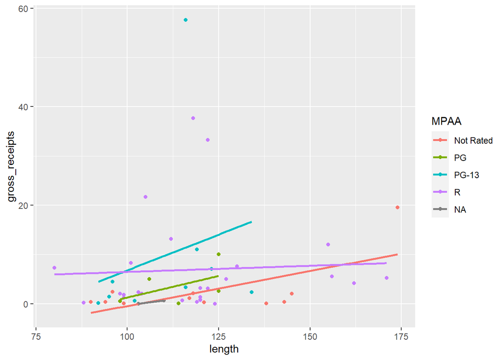

```r
datawide %>%
  group_by(MPAA) %>%
  dplyr::mutate(MPAA_Count = n()) %>%
  rowwise() %>%
  filter(MPAA_Count >= 4) %>%
  ggplot(aes(x = length, y = gross_receipts, color = MPAA)) +
  geom_point() +
  geom_smooth(formula = y ~ x, method = "lm", se = FALSE)
```

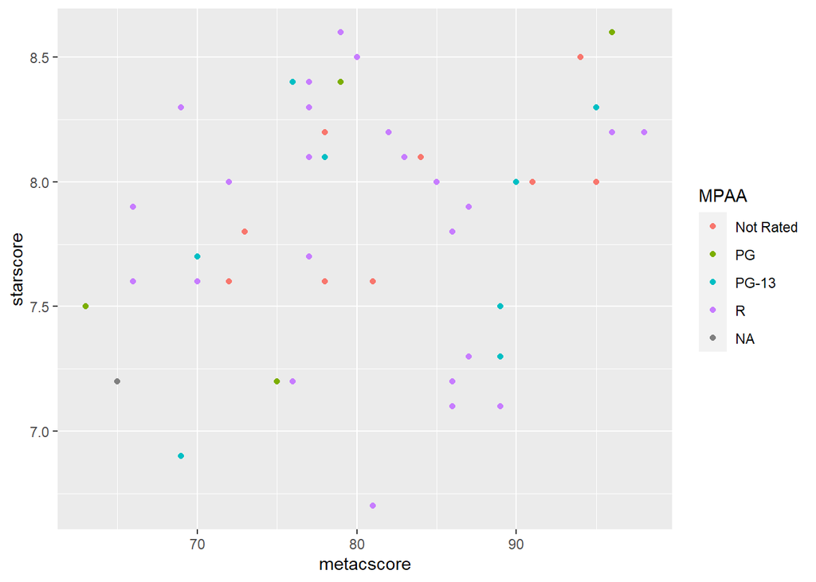

```r
datawide %>%
  group_by(MPAA) %>%
  dplyr::mutate(MPAA_Count = n()) %>%
  rowwise() %>%
  filter(MPAA_Count >= 4, metacscore >= 50, metacscore <= 100) %>%
  ggplot(aes(x = metacscore, y = starscore)) +
  geom_point(aes( color = MPAA))
```

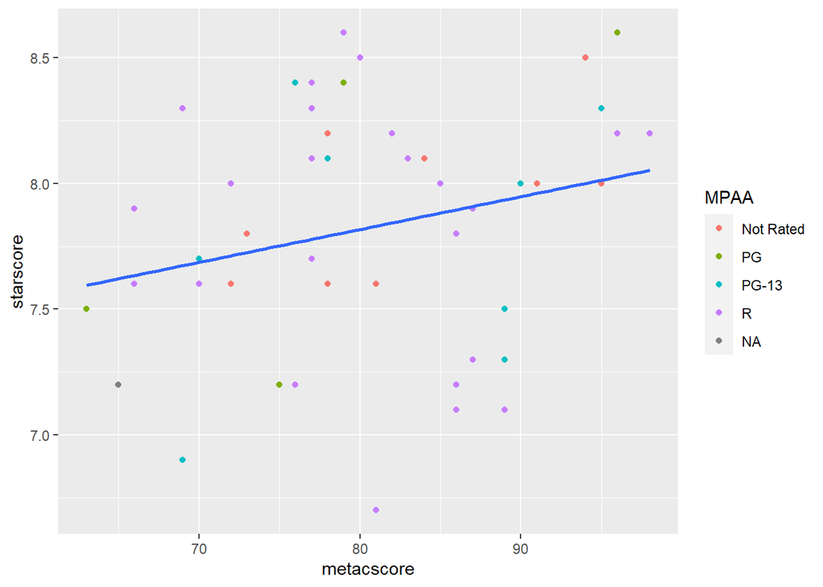

```r
datawide %>%
  group_by(MPAA) %>%
  dplyr::mutate(MPAA_Count = n()) %>%
  rowwise() %>%
  filter(MPAA_Count >= 4, metacscore >= 50, metacscore <= 100) %>%
  ggplot(aes(x = metacscore, y = starscore)) +
  geom_point(aes( color = MPAA)) +
  geom_smooth(formula = y ~ x, method = "lm", se = FALSE)
```

```r
datawide_lm <-  datawide[which(datawide$metacscore >= 50),]
lm_model <- lm(starscore~metacscore, data = datawide_lm)
summary(lm_model)
```

```
##
## Call:
## lm(formula = starscore ~ metacscore, data = datawide_lm)
##
## Residuals:
##     Min      1Q  Median      3Q     Max
## -1.1315 -0.2212  0.0376  0.3022  0.7961
##
## Coefficients:
##             Estimate Std. Error t value Pr(>|t|)
## (Intercept) 6.715267   0.582314  11.532 1.07e-15 ***
## metacscore  0.013781   0.007213   1.911   0.0618 .
## ---
## Signif. codes:  0 '***' 0.001 '**' 0.01 '*' 0.05 '.' 0.1 ' ' 1
##
## Residual standard error: 0.4587 on 50 degrees of freedom
## Multiple R-squared:  0.06804,    Adjusted R-squared:  0.0494
## F-statistic:  3.65 on 1 and 50 DF,  p-value: 0.0618
```

I am surprised at the result since the p-value of the regression is 0.0618 > 0.05 and adjusted R Squared is very small at 0.0494. It means the overall model is not significantly meaningful. However, the plot shows there appear to be positive relationship between metascore and star score.

I think it might because the variance of metascore is too large.Another reason could be there are a few outliers. For example, in the chart, I can see a few movies has quite high metascore but fairly low star score or low metascore but high star score.

[figure not shown]

```r
datawide %>%
  ggplot(aes(x = vote, y = reorder(Country,vote,FUN = mean))) +geom_boxplot() +
  ylab("") +xlab("Votes") + ggtitle("IMDB Votes per Top 100 Foreign Films \n by Country") +
  theme_light()
```

The chart ranked country by the movies average votes in the country. From the chart, we can see Brazil’s movies on average has the highest votes. And a few countries including France, Italy, Spain, South Korea and Japan have a few movies has extraordinary high votes.

```r
datawide %>%
  group_by(first_director) %>%
  dplyr::mutate(num_movies = n(),
         total_gross = sum(gross_receipts, na.rm = T)) %>%
  select(first_director,num_movies, total_gross) %>%
  unique() %>%
  arrange(desc(num_movies)) %>%
  head(5)
```

```
## # A tibble: 5 x 3
## # Groups:   first_director [5]
##   first_director   num_movies total_gross
##   <chr>                 <int>       <dbl>
## 1 Park Chan-Wook            4        2.72
## 2 Jean-Luc Godard           4        0.39
## 3 Hayao Miyazaki            3       13.6
## 4 Federico Fellini          3       20.3
## 5 Pedro Almodóvar           3       16.5
```

```r
# The top 5 first directors with largest total number of movies are:
# Park Chan-Wook, Jean-Luc Godard, Hayao Miyazaki, Federico Fellini, Pedro Almodóvar
```

- Identify the top 5 first directors based on their total gross and the number of movies

```r
datawide %>%
  group_by(first_director) %>%
  dplyr::mutate(num_movies = n(),
         total_gross = sum(gross_receipts, na.rm = T)) %>%
  select(first_director,num_movies, total_gross) %>%
  unique() %>%
  arrange(desc(total_gross)) %>%
  head(5)
```

```
## # A tibble: 5 x 3
## # Groups:   first_director [5]
##   first_director     num_movies total_gross
##   <chr>                   <int>       <dbl>
## 1 Roberto Benigni             1        57.6
## 2 Guillermo del Toro          1        37.6
## 3 Jean-Pierre Jeunet          1        33.2
## 4 Alfonso Arau                1        21.7
## 5 Federico Fellini            3        20.3
```

```r
# The top 5 first directors with largest total gross are:
# Roberto Benigni, Guillermo del Toro, Jean-Pierre Jeunet, Alfonso Arau, Federico Fellini
```

- By just looking at the results, which director appears on both lists? Only director Federico Fellini appears on both lists